# LARSEN_Skills_Test_3

##Task 3 The rest of the test uses another data set. The “Juniper_Oils.csv” data. Get it loaded and take a look. Then tidy it! (show the code used for tidying in your report)

```r
#Let's load in this new data set.
joil<-read.csv("Juniper_Oils.csv")
glimpse(joil)
```

```
## Rows: 34
## Columns: 41
## $ SampleID               <chr> "LOG-16S-SL12", "LOG-16S-SL11", "LOG-16S-CC5", …
## $ Project                <chr> "JuniperLogs", "JuniperLogs", "JuniperLogs", "J…
## $ Amplicon               <chr> "16S", "16S", "16S", "16S", "16S", "16S", "16S"…
## $ Tree_Species           <chr> "Juniperus osteosperma", "Juniperus osteosperma…
## $ BurnYear               <int> 2018, 2017, 2016, 2014, 2013, 2012, 2011, 2009,…
## $ Latitude               <dbl> 41.5719, 40.9202, 37.5799, 39.9422, 41.5335, 40…
## $ Longitude              <dbl> -113.7488, -113.0017, -113.0851, -112.7181, -11…
## $ Field_Office           <chr> "Salt_Lake_3", "Salt_Lake_2", "Cedar_City", "Sa…
## $ BLM_Fire_Name          <chr> "Ridge", "Knob", "Hicks Creek", "Lion Peak", "P…
## $ Tracking_Number        <chr> "#5276 (2018)", "#5275 (2017)", "#5274 (2016)",…
## $ alpha.pinene           <dbl> 0.6, 1.4, 0.2, 0.3, 0.1, 0.0, 0.1, 0.2, 0.1, 0.…
## $ para.cymene            <dbl> 0.4, 0.3, 1.1, 0.1, 0.1, 0.1, 0.5, 0.6, 0.2, 0.…
## $ alpha.terpineol        <dbl> 2.3, 0.5, 0.8, 0.7, 0.2, 0.1, 2.8, 1.1, 0.1, 0.…
```

[output cut: 28 more lines]

```r
#Oh boy, that's, that's awesome.
#Wow. Love the 41 catagories.
#Let's get that bad boy tidied up.
names(joil)[11:33]
```

```
##  [1] "alpha.pinene"      "para.cymene"       "alpha.terpineol"
##  [4] "cedr.9.ene"        "alpha.cedrene"     "beta.cedrene"
##  [7] "cis.thujopsene"    "alpha.himachalene" "beta.chamigrene"
## [10] "cuparene"          "compound.1"        "alpha.chamigrene"
## [13] "widdrol"           "cedrol"            "beta.acorenol"
## [16] "alpha.acorenol"    "gamma.eudesmol"    "beta.eudesmol"
## [19] "alpha.eudesmol"    "cedr.8.en.13.ol"   "cedr.8.en.15.ol"
## [22] "compound.2"        "thujopsenal"
```

```r
#Okay, everything is in the order I want it. Thank you for making that all tidy already.
chemicals <- c(
  "alpha-pinene","para-cymene","alpha-terpineol","cedr-9-ene",
  "alpha-cedrene","beta-cedrene","cis-thujopsene","alpha-himachalene",
  "beta-chamigrene","cuparene","compound 1","alpha-chamigrene",
  "widdrol","cedrol","beta-acorenol","alpha-acorenol",
  "gamma-eudesmol","beta-eudesmol","alpha-eudesmol",
  "cedr-8-en-13-ol","cedr-8-en-15-ol","compound 2","thujopsenal"
)
#Still some issue, but this should deal with that.
joil <- joil |>
  janitor::clean_names()

names(joil)[11:33] <- chemicals
#Alright, let's tidy it more.
tidyjoil <- joil |>
  pivot_longer(
    cols = all_of(chemicals),
    names_to = "compound",
    values_to = "concentration"
  )
tidyjoil <- tidyjoil |>
  filter(!is.na(concentration))
tidyjoil <- tidyjoil |>
  mutate(
    sample_id = as.factor(sample_id),
    compound  = as.factor(compound)
  )
#yay
```

##Task 4 Make me a graph of the following: x = YearsSinceBurn y = Concentration facet = ChemicalID (use free y-axis scales)

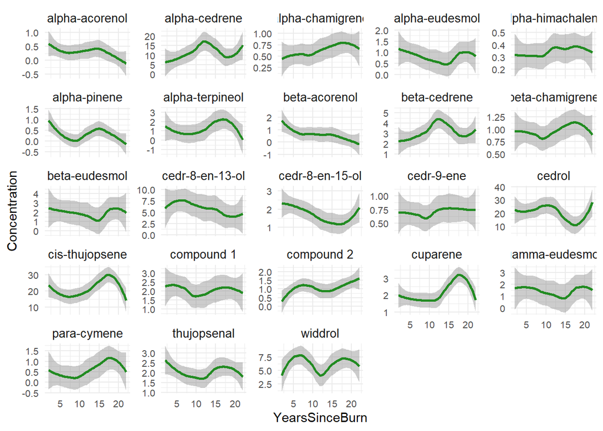

```r
#Oh boy, ggplot, my favorite.
#Can't get enough of this guy after making Withered Foxy
#anyway.
#chaning coils, because, fun.
ggplot(tidyjoil, aes(x = years_since_burn, y = concentration)) +
  geom_smooth(color = "forestgreen", fill = "grey50", size = 1) +
  facet_wrap(~ compound, scales = "free_y", ncol = 5) +
  labs(
    x = "YearsSinceBurn",
    y = "Concentration"
  ) +
  theme_minimal() +
  theme(
    strip.text = element_text(size = 10),
    axis.text = element_text(size = 8)
  )
```

##Task 5 Use a generalized linear model to find which chemicals show concentrations that are significantly (significant, as in P < 0.05) affected by “Years Since Burn”.

```r
#Gonna be so real for this one.
#I didn't really udnerstand, so this one is HEAVILY helped by ChatGPT.
#The others i mainly just ran my code by it.
#This one was like, taught to me by it.
modjoil <-lm(concentration ~ compound * years_since_burn, data = tidyjoil)

glimpse(modjoil)
```

[output not shown]

```r
#ooh, actually, I hate that for this one.
#head(modjoil)
#That's nasty too. So nasty that I commented the line.
#Back to asking for help.
#and tidying it again.
modjoil <- tidy(modjoil)
modjoil
```

```
## # A tibble: 46 × 5
##    term                      estimate std.error statistic   p.value
##    <chr>                        <dbl>     <dbl>     <dbl>     <dbl>
##  1 (Intercept)                 0.547       1.37    0.401  0.689
##  2 compoundalpha-cedrene       7.88        1.93    4.08   0.0000497
##  3 compoundalpha-chamigrene   -0.0972      1.93   -0.0503 0.960
##  4 compoundalpha-eudesmol      0.361       1.93    0.187  0.852
##  5 compoundalpha-himachalene  -0.241       1.93   -0.125  0.901
##  6 compoundalpha-pinene        0.0490      1.93    0.0254 0.980
##  7 compoundalpha-terpineol     0.446       1.93    0.231  0.818
##  8 compoundbeta-acorenol       0.829       1.93    0.429  0.668
##  9 compoundbeta-cedrene        2.12        1.93    1.10   0.273
## 10 compoundbeta-chamigrene     0.366       1.93    0.190  0.850
## # ℹ 36 more rows
```

```r
#okay, this is looking more like what we want.
#Let's do more filtering, to the bits we care about only.
modjoil<- modjoil |>
  dplyr::filter(p.value < 0.05)
modjoil
```

```
## # A tibble: 6 × 5
##   term                                    estimate std.error statistic  p.value
##   <chr>                                      <dbl>     <dbl>     <dbl>    <dbl>
## 1 compoundalpha-cedrene                      7.88      1.93       4.08 4.97e- 5
## 2 compoundcedr-8-en-13-ol                    7.62      1.93       3.95 8.72e- 5
## 3 compoundcedrol                            22.5       1.93      11.7  5.12e-29
## 4 compoundcis-thujopsene                    17.3       1.93       8.95 2.93e-18
## 5 compoundwiddrol                            5.82      1.93       3.01 2.69e- 3
## 6 compoundcis-thujopsene:years_since_burn    0.332     0.141      2.35 1.90e- 2
```

And I think that’s what you wanted from it. Let’s hope it is, because I’m tired, and this is the best we’re getting.